# Kinase Inhibitor Prediction Overview

2022-02-25

This report summarizes the cell viability predictions for your data set. The data you submitted has 110 out of the 110 genes included in the model. For reference, the system assigned your data the ID: 337e57.

# Cell Viability Predictions

To provide context for the predictions from your data, all of the following plots also show a summary of the predictions from the cell lines in the CCLE. The gray shaded region shows the range (95% coverage) of predictions for that compound, while the black line shows the average prediction. Predictions for your data appear as a blue line.

To help pick out potentially interesting compounds from the model predictions, we’ve sorted the predictions using four different methods:

- The compound is predicted to have minimal effects on cell viability.
- The compound is predicted to have high average effect on cell viability.
- The compound is predicted to show a wide range of effect on cell viability.
- The compound is predicted to vary from the CCLE average effect.

These categories are not mutually exclusive, so it’s possible that a single compound will be present in multiple compound sets. Otherwise, the results are displayed as a set of small multiple graphs with the compound name in the title section.

## Minimal Effects

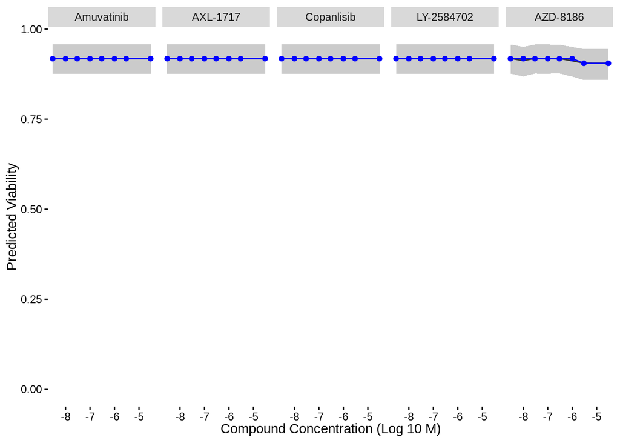

## High Effects

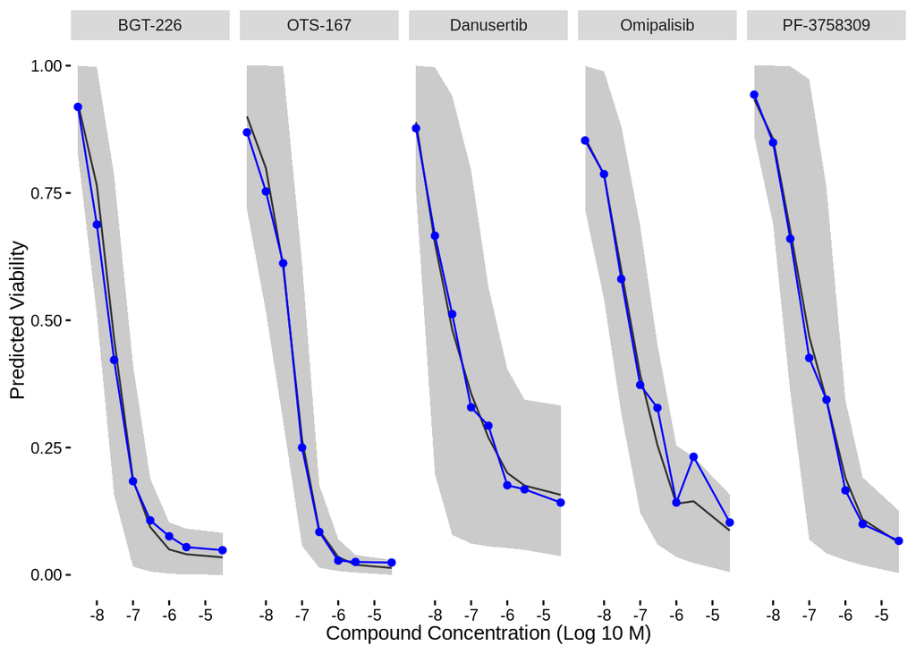

## High Range of Effect

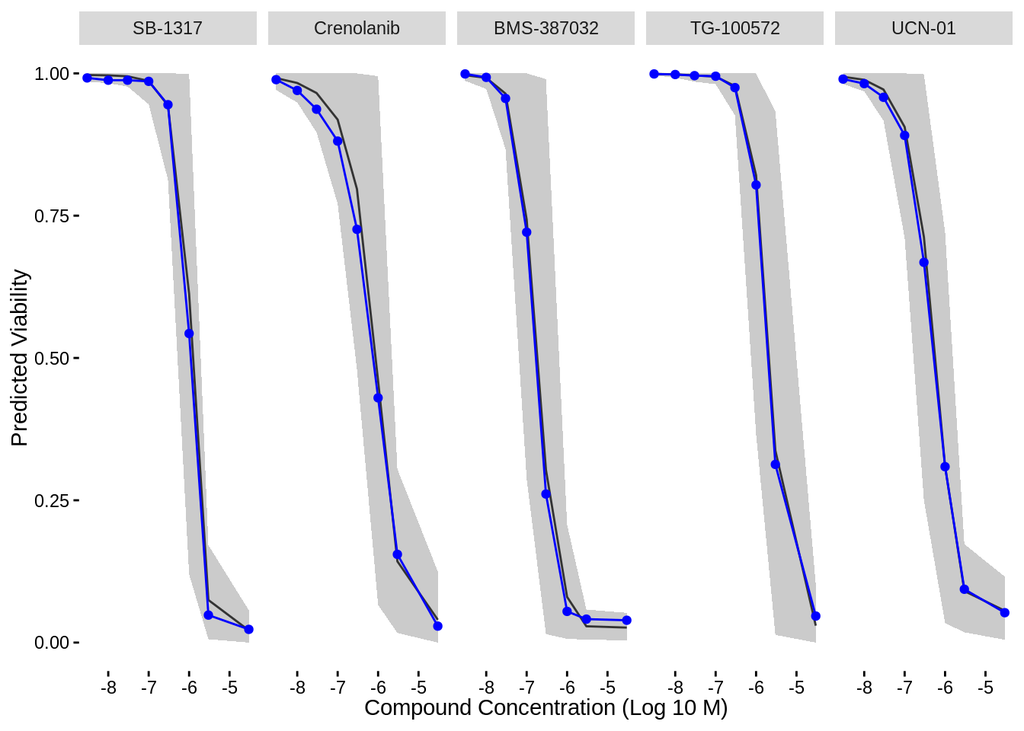

## Largest Difference from CCLE

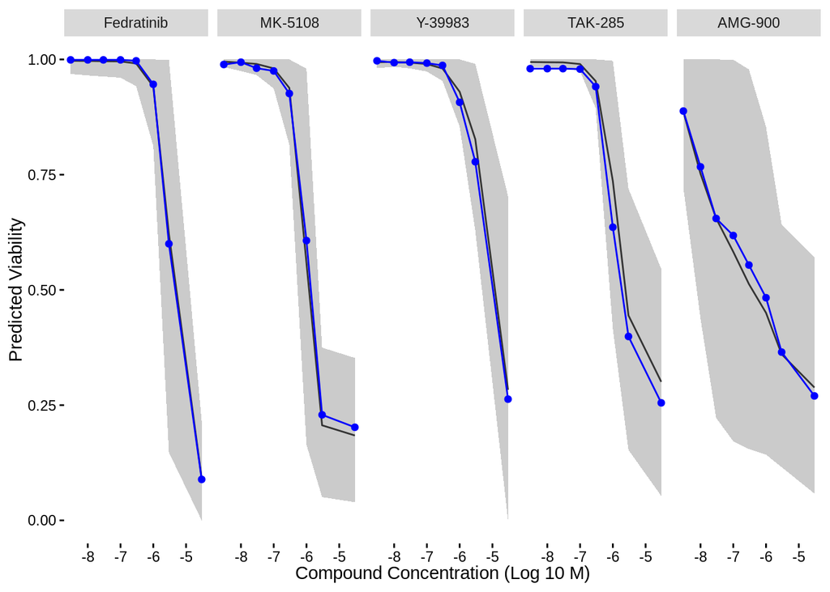